# HW2

clayhku

2024-11-05

# Question 1: Crime Data

```r
library(caret)
library(Metrics)
library(glmnet)
library(leaps)

# load data
crime <- read.csv("CrimeData_sub.csv", stringsAsFactors = F, na.strings = c("?"))
crime <- na.omit(crime)

# divide data into training data and testing data
set.seed(123)
trainIndex <- createDataPartition(crime$violentcrimes.perpop, p = 0.8, list = FALSE)
trainData <- crime[trainIndex, ]
testData <- crime[-trainIndex, ]
```

## Q1.1

```r
# Run the OLS Model
model <- lm(violentcrimes.perpop ~ ., data = trainData)
trainPredictions <- predict(model, trainData)
# Calculate MSE & R-squared for training data
trainMSE <- mean((trainData$violentcrimes.perpop - trainPredictions)^2)
trainR2 <- summary(model)$r.squared
# Calculate MSE & R-squared for training data
testPredictions <- predict(model, testData)
testMSE <- mean((testData$violentcrimes.perpop - testPredictions)^2)
SS_total <- sum((testData$violentcrimes.perpop - mean(testData$violentcrimes.perpop))^2)
SS_residual <- sum((testData$violentcrimes.perpop - testPredictions)^2)
testR2 <- 1 - (SS_residual / SS_total)
# Results
cat("Training MSE:", trainMSE)
```

```
## Training MSE: 77056.83
```

```r
cat("Training R-squared:", trainR2)
```

```
## Training R-squared: 0.8210021
```

```r
cat("Testing MSE:", testMSE)
```

```
## Testing MSE: 181425.9
```

```r
cat("Testing R-squared:", testR2)
```

```
## Testing R-squared: 0.6261147
```

The training MSE is `77056.83` while testing MSE is `181425.9`.  
The Training R-squared is `0.8210021` while testing R-squared is `0.6261147`.  
We can see that there is big difference between training and testing, which includes that the model fail to fit the data very well.

## Q1.2

### i.

```r
x_train <- model.matrix(violentcrimes.perpop ~ ., trainData)[, -1]
y_train <- trainData$violentcrimes.perpop

# 5-folds CV
cv_lasso <- cv.glmnet(x_train, y_train, alpha = 1, nfolds = 5)
lambda_min <- cv_lasso$lambda.min
# lasso regression
lasso_model <- glmnet(x_train, y_train, alpha = 1, lambda = lambda_min)

coefficients = coef(lasso_model)
index <- which(coefficients != 0)

selected_variables <- rownames(coefficients)[index][-1]
selected_variables
```

```
##  [1] "race.pctblack"         "pct.inv.inc"           "male.pct.divorce"
##  [4] "pct.kids2parents"      "pct.youngkids2parents" "pct.workmom"
##  [7] "pct.kids.nvrmarried"   "num.vacant.house"      "pct.house.vacant"
## [10] "med.yr.house.built"    "num.homeless"          "pct.samecity1985"
```

The `race.pctblack, pct.inv.inc, male.pct.divorce, pct.kids2parents, pct.youngkids2parents, pct.workmom, pct.kids.nvrmarried, num.vacant.house, pct.house.vacant, med.yr.house.built, num.homeless, pct.samecity1985` are the names of variables selected by lasso model.

### ii.

```r
# ols regression based on variables selected by lasso
ols_formula <- as.formula(paste("violentcrimes.perpop ~", paste(selected_variables, collapse = " + ")))
ols_model <- lm(ols_formula, data = trainData)

# Caculate MSE and R-squared
trainPredictions_lasso_ols <- predict(ols_model, trainData)
trainMSE_lasso_ols <- mean((trainData$violentcrimes.perpop - trainPredictions_lasso_ols)^2)
trainR2_lasso_ols <- summary(ols_model)$r.squared


testPredictions_lasso_ols <- predict(ols_model, testData)
testMSE_lasso_ols <- mean((testData$violentcrimes.perpop - testPredictions_lasso_ols)^2)

SS_total <- sum((testData$violentcrimes.perpop - mean(testData$violentcrimes.perpop))^2)
SS_residual <- sum((testData$violentcrimes.perpop - testPredictions_lasso_ols)^2)
testR2_lasso_ols <- 1 - (SS_residual / SS_total)

cat("Training MSE:", trainMSE_lasso_ols)
```

```
## Training MSE: 125643.1
```

```r
cat("Training R-squared:", trainR2_lasso_ols)
```

```
## Training R-squared: 0.7081396
```

```r
cat("Testing MSE:", testMSE_lasso_ols)
```

```
## Testing MSE: 125626.3
```

```r
cat("Testing R-squared:", testR2_lasso_ols)
```

```
## Testing R-squared: 0.7411074
```

### iii.

```r
model_all <- regsubsets(ols_formula, data = trainData, method = "exhaustive")
# use bic to select the best model
best_bic_model <- which.min(summary(model_all)$bic)
predictors_bic <- names(coef(model_all, best_bic_model))

formula_bic <- as.formula(paste("violentcrimes.perpop ~", paste(predictors_bic[-1], collapse = " + ")))
final_model <- lm(formula_bic, data = trainData)
summary(final_model)
```

```
##
## Call:
## lm(formula = formula_bic, data = trainData)
##
## Residuals:
##      Min       1Q   Median       3Q      Max
## -1039.39  -204.23   -55.41   151.89  1813.58
##
## Coefficients:
##                     Estimate Std. Error t value Pr(>|t|)
## (Intercept)         3093.461    429.691   7.199 5.22e-12 ***
## race.pctblack         19.849      3.215   6.174 2.24e-09 ***
## pct.kids2parents     -22.733      3.768  -6.034 4.88e-09 ***
## pct.workmom          -15.706      3.898  -4.030 7.14e-05 ***
## pct.kids.nvrmarried   54.916     14.862   3.695 0.000263 ***
## num.homeless          42.444     12.684   3.346 0.000927 ***
## ---
## Signif. codes:  0 '***' 0.001 '**' 0.01 '*' 0.05 '.' 0.1 ' ' 1
##
## Residual standard error: 369 on 290 degrees of freedom
## Multiple R-squared:  0.6902, Adjusted R-squared:  0.6848
## F-statistic: 129.2 on 5 and 290 DF,  p-value: < 2.2e-16
```

```r
print("Final Model:")
```

```
## [1] "Final Model:"
```

```r
print(formula_bic)
```

```
## violentcrimes.perpop ~ race.pctblack + pct.kids2parents + pct.workmom +
##     pct.kids.nvrmarried + num.homeless
```

**PLAN:**  
Use bic to select the best model, then remove the variables which p-values is higher than 0.05. BIC could balance the trade-off between model fit and complexity. And removing variables with high p-value improves the interpretability of the model.  
Based on the analysis, the final model is given by the **formula_bic** above, which achieves the lowest BIC and includes only those coefficients with p-values less than 0.05.

#### iv.

```r
# caculate final model MSE and R-squared
trainPredictions_final <- predict(final_model, trainData)
trainMSE_final <- mean((trainData$violentcrimes.perpop - trainPredictions_final)^2)
trainR2_final <- summary(final_model)$r.squared

testPredictions_final <- predict(final_model, testData)
testMSE_final <- mean((testData$violentcrimes.perpop - testPredictions_final)^2)

SS_total_final <- sum((testData$violentcrimes.perpop - mean(testData$violentcrimes.perpop))^2)
SS_residual_final <- sum((testData$violentcrimes.perpop - testPredictions_final)^2)
testR2_final <- 1 - (SS_residual_final / SS_total_final)

cat("Final Model - Training MSE:", trainMSE_final, "\n")
```

```
## Final Model - Training MSE: 133376.7
```

```r
cat("Final Model - Training R-squared:", trainR2_final, "\n")
```

```
## Final Model - Training R-squared: 0.6901747
```

```r
cat("Final Model - Testing MSE:", testMSE_final, "\n")
```

```
## Final Model - Testing MSE: 135137.3
```

```r
cat("Final Model - Testing R-squared:", testR2_final, "\n")
```

```
## Final Model - Testing R-squared: 0.7215069
```

```r
# cv for ridge
cv_ridge <- cv.glmnet(x_train, y_train, alpha = 0, nfolds = 5)
lambda_ridge <- cv_ridge$lambda.min

# ridge regression
ridge_model <- glmnet(x_train, y_train, alpha = 0, lambda = lambda_ridge)

# Caculate MSE and R-squared
trainPredictions_ridge <- predict(ridge_model, s = lambda_ridge, newx = x_train)
trainMSE_ridge <- mean((y_train - trainPredictions_ridge)^2)
trainR2_ridge <- 1 - sum((y_train - trainPredictions_ridge)^2) / sum((y_train - mean(y_train))^2)


x_test <- model.matrix(violentcrimes.perpop ~ ., testData)[, -1]
testPredictions_ridge <- predict(ridge_model, s = lambda_ridge, newx = x_test)
testMSE_ridge <- mean((testData$violentcrimes.perpop - testPredictions_ridge)^2)

SS_total_ridge <- sum((testData$violentcrimes.perpop - mean(testData$violentcrimes.perpop ))^2)
SS_residual_ridge <- sum((testData$violentcrimes.perpop - testPredictions_ridge)^2)
testR2_ridge <- 1 - (SS_residual_ridge / SS_total_ridge)

cat("Ridge Regression - Training MSE:", trainMSE_ridge)
```

```
## Ridge Regression - Training MSE: 130533.5
```

```r
cat("Ridge Regression - Training R-squared:", trainR2_ridge)
```

```
## Ridge Regression - Training R-squared: 0.6967795
```

```r
cat("Ridge Regression - Testing MSE:", testMSE_ridge)
```

```
## Ridge Regression - Testing MSE: 131724.7
```

```r
cat("Ridge Regression - Testing R-squared:", testR2_ridge)
```

```
## Ridge Regression - Testing R-squared: 0.7285397
```

The results of Ridge Regression also performs well, there is no big differenence between the final model and the ridge regression from the perspective of MSE or R-squared. However, ridge regression have no effect on model selection, which indicates that there could be too many variables in ridge regression model and may lead to overfitting problems when using other dataset.

# Question 2: Default Data from ISLR

## Q2.1

```r
library(ISLR)
data(Default)

logistic_model <- glm(default ~ student, data = Default, family = "binomial")
summary(logistic_model)
```

```
##
## Call:
## glm(formula = default ~ student, family = "binomial", data = Default)
##
## Coefficients:
##             Estimate Std. Error z value Pr(>|z|)
## (Intercept) -3.50413    0.07071  -49.55  < 2e-16 ***
## studentYes   0.40489    0.11502    3.52 0.000431 ***
## ---
## Signif. codes:  0 '***' 0.001 '**' 0.01 '*' 0.05 '.' 0.1 ' ' 1
##
## (Dispersion parameter for binomial family taken to be 1)
##
##     Null deviance: 2920.6  on 9999  degrees of freedom
## Residual deviance: 2908.7  on 9998  degrees of freedom
## AIC: 2912.7
##
## Number of Fisher Scoring iterations: 6
```

**Intercept:** This represents the log-odds of the default status of baseline.(Student: No) **Coefficient:** This represents the default status change of log-odds from non-student to student.  
For X variable, the p-value is lower than 0.05, so it is significant.

## Q2.2

### i.

```r
full_model <- glm(default ~ ., data = Default, family = "binomial")
summary(full_model)
```

```
##
## Call:
## glm(formula = default ~ ., family = "binomial", data = Default)
##
## Coefficients:
##               Estimate Std. Error z value Pr(>|z|)
## (Intercept) -1.087e+01  4.923e-01 -22.080  < 2e-16 ***
## studentYes  -6.468e-01  2.363e-01  -2.738  0.00619 **
## balance      5.737e-03  2.319e-04  24.738  < 2e-16 ***
## income       3.033e-06  8.203e-06   0.370  0.71152
## ---
## Signif. codes:  0 '***' 0.001 '**' 0.01 '*' 0.05 '.' 0.1 ' ' 1
##
## (Dispersion parameter for binomial family taken to be 1)
##
##     Null deviance: 2920.6  on 9999  degrees of freedom
## Residual deviance: 1571.5  on 9996  degrees of freedom
## AIC: 1579.5
##
## Number of Fisher Scoring iterations: 8
```

### ii.

```r
library(pROC)
```

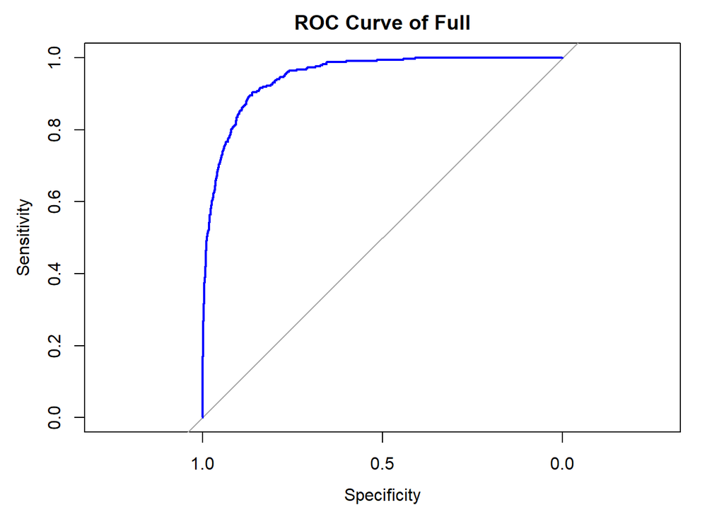

```r
pred_full <- predict(full_model, type = "response")
pred_student <- predict(logistic_model, type = "response")
actual <- Default$default
roc_curve_full <- roc(actual, pred_full)
roc_curve_student <- roc(actual, pred_student)
plot(roc_curve_full, main = "ROC Curve of Full", col = "blue")
```

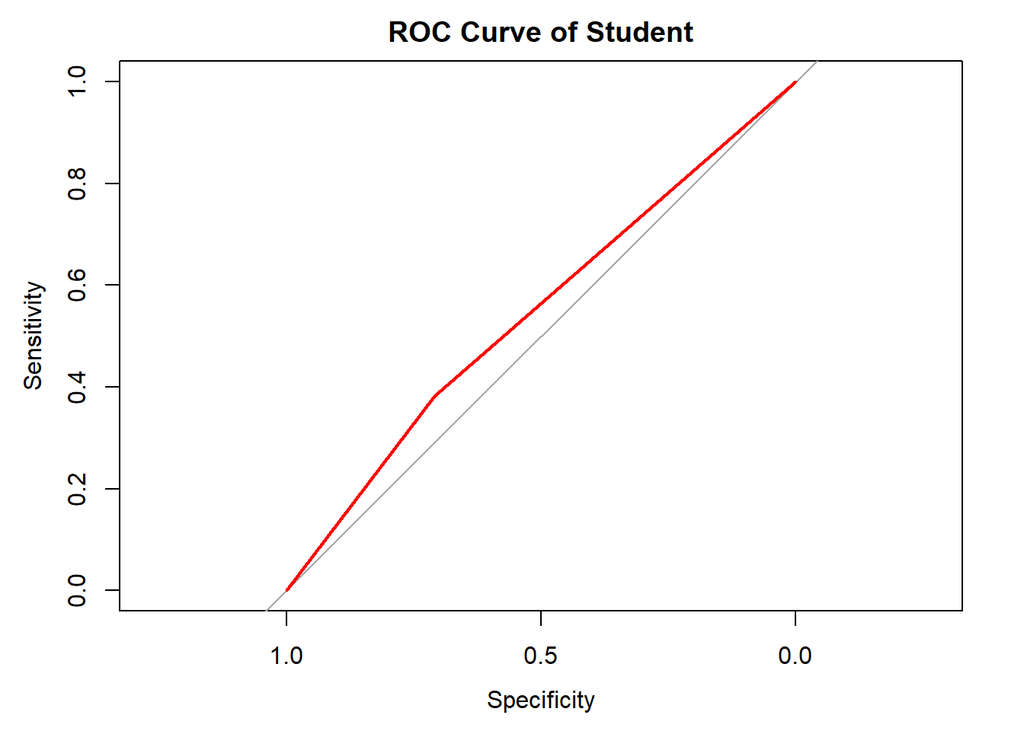

```r
plot(roc_curve_student, main = "ROC Curve of Student", col = "red")
```

```r
auc_value_full <- auc(roc_curve_full)
auc_value_student <- auc(roc_curve_student)

cat("AUC of Full model:", auc_value_full)
```

```
## AUC of Full model: 0.9495581
```

```r
cat("AUC of Student model:", auc_value_student)
```

```
## AUC of Student model: 0.5449888
```

From ROC curve, we can see that full model behaves better, because its ROC curve is closer to the top-left corner of the plot. The AUC shows the idea in a more specific way. The AUC of full model is `0.9495581` while the AUC of student model is `0.5449888`. We can find that the AUC of full model is much higher, which indicates a better model prediction.

### iii.

```r
pred_full_binary <- ifelse(pred_full > 0.5, "Yes", "No")
confusion_matrix <- table(Predicted = pred_full_binary, Actual = Default$default)

TP <- confusion_matrix["Yes", "Yes"]  # True Positives
TN <- confusion_matrix["No", "No"]    # True Negatives
FP <- confusion_matrix["Yes", "No"]   # False Positives
FN <- confusion_matrix["No", "Yes"]   # False Negatives

sensitivity <- TP / (TP + FN)
specificity <- TN / (TN + FP)
FPR <- FP / (FP + TN)
TPR <- TP / (TP + FN)

cat("Results:")
```

```
## Results:
```

```r
cat("Sensitivity (True Positive Rate):", sensitivity)
```

```
## Sensitivity (True Positive Rate): 0.3153153
```

```r
cat("Specificity:", specificity)
```

```
## Specificity: 0.9958622
```

```r
cat("False Positive Rate:", FPR)
```

```
## False Positive Rate: 0.004137788
```

```r
cat("True Positive Rate:", TPR)
```

```
## True Positive Rate: 0.3153153
```

# Question 3: Lost Sales

```r
# load data
data <- read.table("lostsales.txt", header = TRUE, sep = ",")
# Convert to factor
data$Part.Type <- as.factor(data$Part.Type)
data$Status <- as.factor(data$Status)

# full model
full_model <- glm(Status ~ ., data = data, family = binomial)
summary(full_model)
```

```
##
## Call:
## glm(formula = Status ~ ., family = binomial, data = data)
##
## Coefficients:
##                    Estimate Std. Error z value Pr(>|z|)
## (Intercept)       7.768e-01  1.712e-01   4.537 5.70e-06 ***
## Quote            -1.931e-05  3.073e-05  -0.628   0.5299
## Time.to.Delivery -1.837e-02  3.483e-03  -5.274 1.34e-07 ***
## Part.TypeOE      -4.711e-01  1.968e-01  -2.394   0.0167 *
## ---
## Signif. codes:  0 '***' 0.001 '**' 0.01 '*' 0.05 '.' 0.1 ' ' 1
##
## (Dispersion parameter for binomial family taken to be 1)
##
##     Null deviance: 762.40  on 549  degrees of freedom
## Residual deviance: 723.83  on 546  degrees of freedom
## AIC: 731.83
##
## Number of Fisher Scoring iterations: 4
```

```r
# use aic to pick best model
aic_model <- step(full_model, direction = "both")
```

```
## Start:  AIC=731.83
## Status ~ Quote + Time.to.Delivery + Part.Type
##
##                    Df Deviance    AIC
## - Quote             1   724.22 730.22
## <none>                  723.83 731.83
## - Part.Type         1   729.61 735.61
## - Time.to.Delivery  1   756.62 762.62
##
## Step:  AIC=730.22
## Status ~ Time.to.Delivery + Part.Type
##
##                    Df Deviance    AIC
## <none>                  724.22 730.22
## + Quote             1   723.83 731.83
## - Part.Type         1   730.13 734.13
## - Time.to.Delivery  1   756.91 760.91
```

```r
coefs = coef(aic_model)
summary(aic_model)
```

```
##
## Call:
## glm(formula = Status ~ Time.to.Delivery + Part.Type, family = binomial,
##     data = data)
##
## Coefficients:
##                   Estimate Std. Error z value Pr(>|z|)
## (Intercept)       0.723499   0.148345   4.877 1.08e-06 ***
## Time.to.Delivery -0.018344   0.003484  -5.266 1.39e-07 ***
## Part.TypeOE      -0.475768   0.196582  -2.420   0.0155 *
## ---
## Signif. codes:  0 '***' 0.001 '**' 0.01 '*' 0.05 '.' 0.1 ' ' 1
##
## (Dispersion parameter for binomial family taken to be 1)
##
##     Null deviance: 762.40  on 549  degrees of freedom
## Residual deviance: 724.22  on 547  degrees of freedom
## AIC: 730.22
##
## Number of Fisher Scoring iterations: 4
```

The Quote variable is statistically insignificant. The coefficient for Time.to.Delivery indicates that for each additional day of delivery time, the log(odds) decreases by approximately `-0.018344`. The coefficient for Part.TypeOE shows that when the part type is original equipment (OE) compared to the aftermarket (AM), the log(odds) decreases by approximately `-0.4757676`.

From the results, it can be seen that whether customers place an order is closely related to delivery time and part type, but it is not associated with price. So, when the part type is AM and delivery time is small, customer will more likely to place an order.

# Question 4: Wine Quality

## i.

```r
library(reshape2)
library(corrplot)
# load data
data <- read.table("winequality-bc.txt", header = TRUE, sep = ",")

data$Quality <- factor(data$Quality,
                       levels = c("Bad", "Just OK", "Good"),
                       ordered = TRUE)
data$color <- as.factor(data$color)

summary(data)
```

```
##     Quality     fixed.acidity    volatile.acidity  citric.acid
##  Bad    : 246   Min.   : 3.800   Min.   :0.0800   Min.   :0.0000
##  Just OK:4974   1st Qu.: 6.400   1st Qu.:0.2300   1st Qu.:0.2500
##  Good   :1277   Median : 7.000   Median :0.2900   Median :0.3100
##                 Mean   : 7.215   Mean   :0.3397   Mean   :0.3186
##                 3rd Qu.: 7.700   3rd Qu.:0.4000   3rd Qu.:0.3900
##                 Max.   :15.900   Max.   :1.5800   Max.   :1.6600
##  residual.sugar     chlorides       free.sulfur.dioxide total.sulfur.dioxide
##  Min.   : 0.600   Min.   :0.00900   Min.   :  1.00      Min.   :  6.0
##  1st Qu.: 1.800   1st Qu.:0.03800   1st Qu.: 17.00      1st Qu.: 77.0
##  Median : 3.000   Median :0.04700   Median : 29.00      Median :118.0
##  Mean   : 5.443   Mean   :0.05603   Mean   : 30.53      Mean   :115.7
##  3rd Qu.: 8.100   3rd Qu.:0.06500   3rd Qu.: 41.00      3rd Qu.:156.0
##  Max.   :65.800   Max.   :0.61100   Max.   :289.00      Max.   :440.0
##     density             pH          sulphates         alcohol        color
##  Min.   :0.9871   Min.   :2.720   Min.   :0.2200   Min.   : 8.00   red  :1599
##  1st Qu.:0.9923   1st Qu.:3.110   1st Qu.:0.4300   1st Qu.: 9.50   white:4898
##  Median :0.9949   Median :3.210   Median :0.5100   Median :10.30
##  Mean   :0.9947   Mean   :3.219   Mean   :0.5313   Mean   :10.49
##  3rd Qu.:0.9970   3rd Qu.:3.320   3rd Qu.:0.6000   3rd Qu.:11.30
##  Max.   :1.0390   Max.   :4.010   Max.   :2.0000   Max.   :14.90
##     quality      Crossvalidation   Hold.Test
##  Min.   :3.000   Min.   :1.000   Min.   :0.0000
##  1st Qu.:5.000   1st Qu.:1.000   1st Qu.:0.0000
##  Median :6.000   Median :2.000   Median :0.0000
##  Mean   :5.818   Mean   :2.024   Mean   :0.5918
##  3rd Qu.:6.000   3rd Qu.:3.000   3rd Qu.:1.0000
##  Max.   :9.000   Max.   :3.000   Max.   :2.0000
```

```r
str(data)
```

```
## 'data.frame':    6497 obs. of  16 variables:
##  $ Quality             : Ord.factor w/ 3 levels "Bad"<"Just OK"<..: 2 2 2 2 2 2 2 3 3 2 ...
##  $ fixed.acidity       : num  7.4 7.8 7.8 11.2 7.4 7.4 7.9 7.3 7.8 7.5 ...
##  $ volatile.acidity    : num  0.7 0.88 0.76 0.28 0.7 0.66 0.6 0.65 0.58 0.5 ...
##  $ citric.acid         : num  0 0 0.04 0.56 0 0 0.06 0 0.02 0.36 ...
##  $ residual.sugar      : num  1.9 2.6 2.3 1.9 1.9 1.8 1.6 1.2 2 6.1 ...
##  $ chlorides           : num  0.076 0.098 0.092 0.075 0.076 0.075 0.069 0.065 0.073 0.071 ...
##  $ free.sulfur.dioxide : num  11 25 15 17 11 13 15 15 9 17 ...
##  $ total.sulfur.dioxide: num  34 67 54 60 34 40 59 21 18 102 ...
##  $ density             : num  0.998 0.997 0.997 0.998 0.998 ...
##  $ pH                  : num  3.51 3.2 3.26 3.16 3.51 3.51 3.3 3.39 3.36 3.35 ...
##  $ sulphates           : num  0.56 0.68 0.65 0.58 0.56 0.56 0.46 0.47 0.57 0.8 ...
##  $ alcohol             : num  9.4 9.8 9.8 9.8 9.4 9.4 9.4 10 9.5 10.5 ...
##  $ color               : Factor w/ 2 levels "red","white": 1 1 1 1 1 1 1 1 1 1 ...
##  $ quality             : int  5 5 5 6 5 5 5 7 7 5 ...
##  $ Crossvalidation     : int  3 2 2 3 3 2 3 3 3 2 ...
##  $ Hold.Test           : int  0 1 1 0 0 0 0 0 0 0 ...
```

```r
# exploratory data analysis
melted_data <- melt(data, id.vars = "Quality")
```

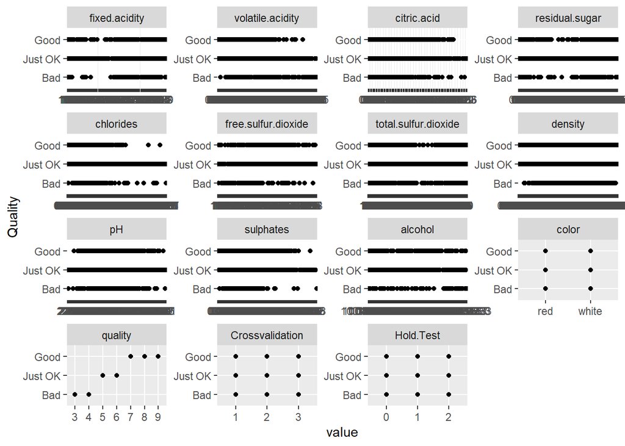

```r
ggplot(melted_data, aes(x = value, y = Quality)) +
  geom_point() +
  facet_wrap(~variable, scales = "free")
```

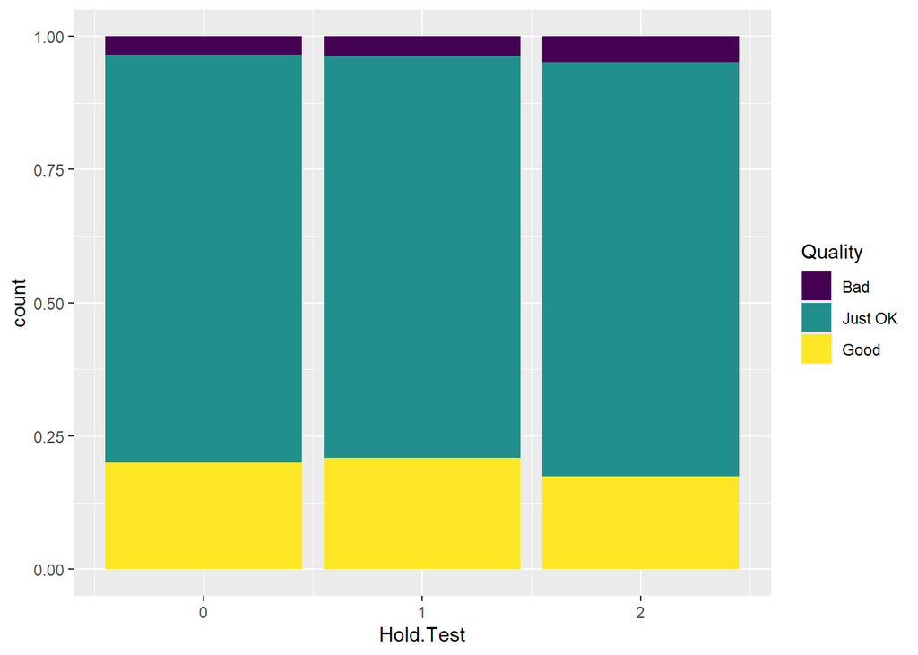

```r
ggplot(data, aes(x = Hold.Test)) +
  geom_bar(aes(fill = Quality), position = "fill")
```

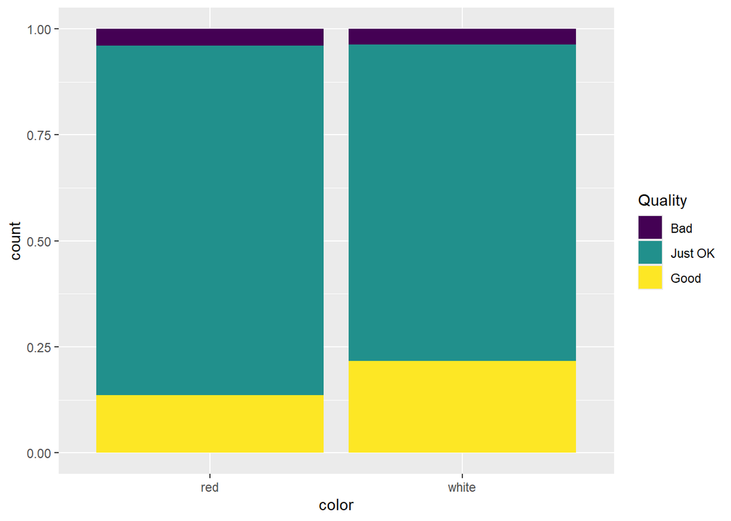

```r
ggplot(data, aes(x = color)) +
  geom_bar(aes(fill = Quality), position = "fill")
```

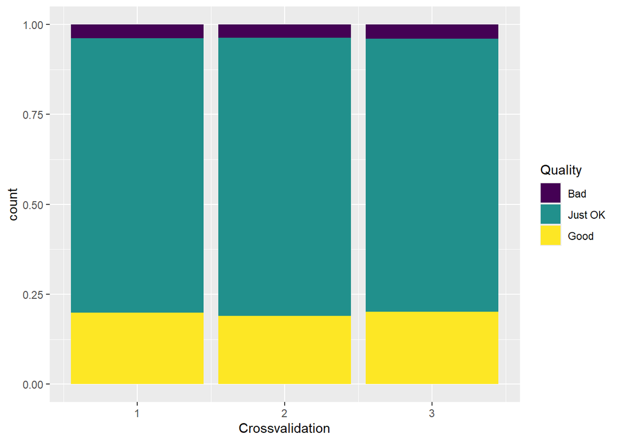

```r
ggplot(data, aes(x = Crossvalidation)) +
  geom_bar(aes(fill = Quality), position = "fill")
```

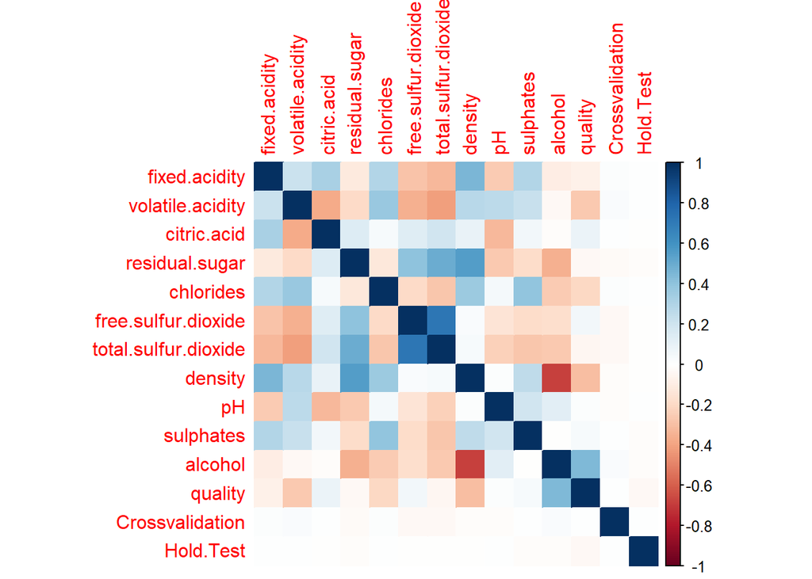

```r
cor_matrix <- cor(data[, -which(names(data) %in% c("Quality", "color"))])
corrplot(cor_matrix, method = "color")
```

```r
# remove unreasonable variables
data <- data[, -c(which(names(data) %in% c("quality", "free.sulfur.dioxide", "Crossvalidation", "Hold.Test", "color")))]

# split training and testing data
set.seed(123)
train_indices <- sample(1:nrow(data), size = 0.8 * nrow(data))
train_data <- data[train_indices, ]
test_data <- data[-train_indices, ]
```

## ii.

```r
# multinominal logistic regression
library(nnet)
library(MASS)
multinom_model <- multinom(Quality ~ ., data = train_data)
summary(multinom_model)
```

```
## Call:
## multinom(formula = Quality ~ ., data = train_data)
##
## Coefficients:
##         (Intercept) fixed.acidity volatile.acidity citric.acid residual.sugar
## Just OK  -254.61730    -0.2810456        -4.014395 -0.06170332    -0.01362941
## Good       40.94839     0.1478147        -7.392564 -0.27422618     0.17159606
##         chlorides total.sulfur.dioxide   density         pH sulphates   alcohol
## Just OK  4.492910         -0.001020684 257.87126 -0.4990153  1.588828 0.5256329
## Good    -1.897636         -0.004600849 -58.23593  1.8980010  4.171905 1.0801204
##
## Std. Errors:
##         (Intercept) fixed.acidity volatile.acidity citric.acid residual.sugar
## Just OK   0.3267691    0.06486095        0.4294484   0.6064961     0.02165785
## Good      0.3089812    0.07143625        0.5640293   0.7002678     0.02351853
##         chlorides total.sulfur.dioxide   density        pH sulphates    alcohol
## Just OK 1.2240069          0.001648664 0.3215302 0.2991026 0.6804182 0.07467489
## Good    0.9454547          0.001862040 0.2999945 0.3002641 0.7178190 0.08083822
##
## Residual Deviance: 5600.576
## AIC: 5644.576
```

```r
# ordinal logistic regression
ordinal_model <- polr(Quality ~ ., data = train_data, Hess = TRUE)
summary(ordinal_model)
```

```
## Call:
## polr(formula = Quality ~ ., data = train_data, Hess = TRUE)
##
## Coefficients:
##                           Value Std. Error   t value
## fixed.acidity           0.25194  0.0365504    6.8931
## volatile.acidity       -3.48860  0.2911554  -11.9819
## citric.acid            -0.09709  0.3135727   -0.3096
## residual.sugar          0.14223  0.0093374   15.2318
## chlorides              -1.09549  1.3317163   -0.8226
## total.sulfur.dioxide   -0.00283  0.0008593   -3.2933
## density              -201.82172  0.5232756 -385.6892
## pH                      1.63310  0.2545901    6.4146
## sulphates               2.32852  0.2605771    8.9360
## alcohol                 0.61821  0.0364197   16.9746
##
## Intercepts:
##              Value     Std. Error t value
## Bad|Just OK  -190.6372    0.5363  -355.4402
## Just OK|Good -185.0177    0.5594  -330.7358
##
## Residual Deviance: 5722.174
## AIC: 5746.174
```

```r
# compare two model
multinom_good <- coef(multinom_model)["Good",]
ordinal_good <- coef(ordinal_model)

multinom_good
```

```
##          (Intercept)        fixed.acidity     volatile.acidity
##         40.948389846          0.147814680         -7.392564185
##          citric.acid       residual.sugar            chlorides
##         -0.274226177          0.171596059         -1.897635836
## total.sulfur.dioxide              density                   pH
##         -0.004600849        -58.235926451          1.898000976
##            sulphates              alcohol
##          4.171904903          1.080120428
```

```r
ordinal_good
```

```
##        fixed.acidity     volatile.acidity          citric.acid
##         2.519442e-01        -3.488603e+00        -9.708799e-02
##       residual.sugar            chlorides total.sulfur.dioxide
##         1.422257e-01        -1.095485e+00        -2.829869e-03
##              density                   pH            sulphates
##        -2.018217e+02         1.633095e+00         2.328524e+00
##              alcohol
##         6.182090e-01
```

### **Multinominal logistic regression:**

**Positive Influences:** Good quality wines are positively associated with higher levels of fixed acidity, residual sugar, pH, sulphates and alcohol.  
**Negative Influences:** Good quality wines are negatively associated with higher levels of volatile acidity, citric acid, chlorides and density.  
**Little Influences:** The coefficient of total sulfur dioxide is too small, showing little influences on good quality.

### **Ordinal logistic regression:**

**Positive Influences:** Good quality wines are positively associated with higher levels of fixed acidity, residual sugar, pH, sulphates and alcohol.  
**Negative Influences:** Good quality wines are negatively associated with higher levels of volatile acidity, citric acid, chlorides and density. **Little Influences:** The coefficient of total sulfur dioxide is too small, showing little influences on good quality.

### **Compare two models:**

Both models agree that lower levels of volatile acidity, citric acid and chlorides, along with higher levels of fixed acidity, residual sugar, sulphates, alcohol, and pH, are associated with better wine quality. Additionally, both models indicate that density has a strong negative correlation with quality. Also, both models find that total sulfur dioxide have a very limited influence. As a result, it seems that we can get similar conclusions through two models.

```r
# compare two models with test data
mlogit_pred <- as.factor(predict(multinom_model, newdata = test_data, type = "class"))
polr_pred <- as.factor(predict(ordinal_model, newdata = test_data, type = "class"))

same_pred_count <- sum(mlogit_pred == polr_pred)
total_count <- nrow(test_data)
diff_rate <- 1 - same_pred_count / total_count
cat("different rate:", diff_rate)
```

```
## different rate: 0.01692308
```

```r
test_data$Quality <- factor(test_data$Quality, ordered=FALSE)
mlogit_accuracy <- mean(mlogit_pred == test_data$Quality)
polr_accuracy <- mean(polr_pred == test_data$Quality)
cat("Multinominal accuracy：", mlogit_accuracy)
```

```
## Multinominal accuracy： 0.7946154
```

```r
cat("Ordinal accuracy：", polr_accuracy)
```

```
## Ordinal accuracy： 0.79
```

From the results above, we can see that two models show similar accuracy. And two models give similar prediction when using the same data, the different rate of two models predicting test data is only `0.0169231`, which is small enough to show that the two models usually gives the same prediction. So we can say that we roughly get similar conclusions using those two models.